# ImageMagickの使い方サンプル

書いた人: lpre_ys

- 前置き
  - 動作環境
  - 事前準備
- 画像の結合
  - エフェクト画像の結合
  - 顔グラ画像の結合
- 画像の分割
  - エフェクト画像
  - 歩行グラ
- 少し特殊な画像結合
  - 余白を下に足して縦に結合する
  - 余白を右に足して横に結合する
- 画像に描画する
  - シンプルな黒文字画像
  - ツクールっぽい、グラデーションに影がついた文字画像を作るコマンド
  - 背景に画像を指定した文字画像を作る
  - 画像にツクールのボーダーを付ける
  - 応用-ツクールのメッセージウィンドウ風画像
- UI画像の自動生成
  - 基本編
  - 合成モードを利用した、すこし複雑な合成
- ツクール2000系で、疑似的に4倍の色数でピクチャ表示を行う
  - 原理
  - ImageMagickコマンド
  - シェル版
- あとがき

## 前置き

中の人がtktk時によく使っている、ImageMagickのコマンドについての解説ドキュメントです。  
magic-potの為だけに入れるのは勿体ないツールなので、ぜひ使ってみてください。

以下のコマンドについてご質問等ございましたら、お気軽にどうぞ。

### 動作環境

中の人は、WSLという、Windows上でLinux（Ubuntu）が動くヤツをつかって開発しています。  
序盤の、1～2行で終わるコマンドの場合、Windowsでもコピペで動きますが、複数行にわたるコマンドは書き替えが必要になります。  
書き替えが必要なコマンドに対しては、初回に限り、Windows版のコマンドも載せていますが、全てのコマンドには対応しておりません。  
Windows版のコマンドが無い物については、ご自身で書き換えてご利用ください。

### 事前準備

一部コマンドでは、中間画像を生成しています。  
それらは邪魔なので、作業フォルダ直下にある、tmpフォルダに生成するようにしています。事前に用意しておいてください。

その他、必要とする画像は、全て作業フォルダ直下に置いてある想定です。

また、コマンドは全て、作業フォルダに入ってから実行しています。

## 画像の結合

### エフェクト画像の結合

こんな感じで、エフェクト用の連番画像が用意されていた場合、次のコマンドで、1発でツクール2k用のエフェクト画像に結合できる。  
※パレットの並び替えは、ImageMaigckには無理なので、読み込み時に透明色を指定するなり、magic-potで一括変換するなりしてください。

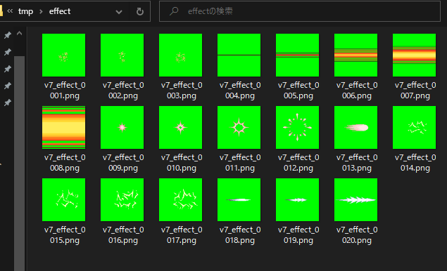

エフェクト-in

#### コマンド、結果

```
magick montage v7_effect_* -geometry +0+0 -tile 5x png8:v7_effect.png
```

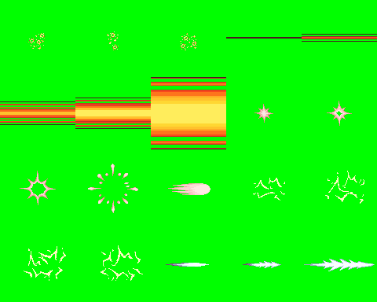

エフェクト-out

フォント周りのエラーが出ますが、無視して問題ありません。

`-tile 5x` で、入力画像を、横5枚で並べて結合、という指示。  
右端、出力画像名の前の`png8:`は、インデックスカラーPNGで保存、という意味です。

### 顔グラ画像の結合

エフェクト同様、連番画像を用意しておけば、次の画像で合成可能。

#### コマンド

```
magick montage face_* -geometry +0+0 -tile 4x4 -resize 192x face.png
```

顔グラの場合、減色は別ソフトでやるので、インデックスカラーの指定は行わない。

顔グラは、2倍 or 4倍のサイズで作画することが多いので、リサイズもこのタイミングで行っている。  
`-resize 192x`で、横幅192に縦横比を保ってリサイズ、という指示。

あとは、別ソフトで減色しておわり。

## 画像の分割

### エフェクト画像

こんな感じのエフェクト画像を、1コマずつバラしたい場合

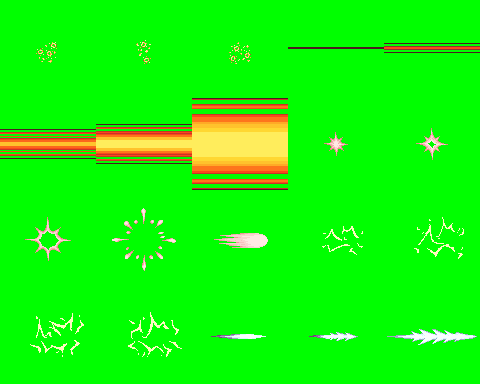

エフェクト-out

#### コマンド、結果

```
magick v7_effect.png -crop 96x96 v7_effect.png
```

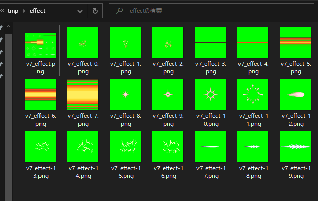

エフェクト-crop

`-crop`オプションの引数として、1コマの画像サイズを指定する。

ファイル名はには、自動的でハイフンと連番が付与される。  
連番とファイル名の区切りを`_`にしたい、など、出力ファイル名のフォーマットを変える場合は下記のように、`%d`を使うと、そこに連番が入ったファイル名で生成される。

```
magick v7_effect.png -crop 96x96 v7_effect_crop_%d.png
```

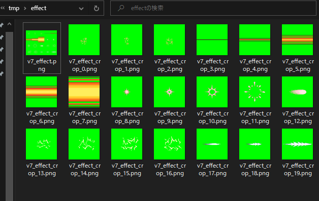

エフェクト-crop2

### 歩行グラ

歩行グラのように、縦横のサイズが違う画像も、もちろん可能

#### コマンド

```
magick 歩行グラ.png -crop 24x32 output.png
```

`-crop`に限らず、ImageMagickのコマンドでは、縦横は「横x縦」という表記になります。

## 少し特殊な画像結合

### 余白を下に足して縦に結合する

次のような、ツクールの「ピクチャの移動」で切り替わったように見せるため、縦長の画像を作るには。  
※スペースの都合上、縦に縮めて表示しています。Chromeの場合、右クリック->新しいタブで画像を開く、とすると原寸表示できます。

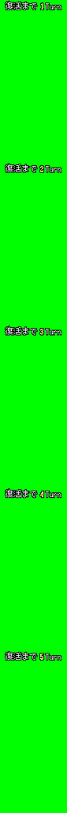

#### コマンド、結果

```
magick mogrify -background '#00FF00' -gravity north -extent 100x240 revive-*.png
magick revive-*.png -append revive-v.png
```

※入力元画像を上書きします！

2つのコマンドにわけて実行しています。

- 1行: 入力の各画像に対して、余白を下に塗り足す
- 2行: 各コマの画像を、縦に並べて結合

100が画像の横幅です。  
画像サイズに合わせて変更してください。

`-gravity north`が、余白生成時に、元画像をどの位置に置くかを表しています。  
north(北)なので、上側。  
この指定を忘れると、画像が中央になってしまいます。

### 余白を右に足して横に結合する

#### コマンド

```
magick mogrify -background '#00FF00' -gravity west -extent 320x16 revive-*.png
magick revive-*.png +append revive-h.png
```

16が画像の縦幅です。  
画像サイズに合わせて変更してください。

`+append` と、appendオプションを`+`にする事により、入力された複数の画像を、横に結合できます。

今回は、画像を左寄せにして余白を作りたいので、`-gravity west`を指定しています。

## 画像に描画する

ここから、コマンドが複雑になるため、Windowsのコマンドプロンプトでは動作しなくなります。  
初回のみ、Windows版のコマンドと、書き替えが必要な個所について説明を入れておきますので、以後、必要であればご自身で書き換えてご利用ください。

### シンプルな黒文字画像

#### 事前準備

フォントは、フリーフォントのPixelMplusの12ポイントの物を利用します。

※MSゴシックだとドットフォントの利用が上手く出来なかったので、似たような代替フォントで対応。

インストールは下記サイトからどうぞ。  
http://itouhiro.hatenablog.com/entry/20130602/font

#### コマンド

##### Linux(Bash)

```
magick -size 200x200 xc:#00FF00 \
  -font '/mnt/c/Windows/Fonts/PixelMplus12-Regular.ttf' -pointsize 12 +antialias \
  -fill '#000000' -gravity north -annotate 0x0 'テスト文字\n改行はこう書くと出来る' \
  -trim text1.png
```

##### Windows(コマンドプロンプト)

```
magick -size 200x200 xc:#00FF00 ^
  -font "c:/Windows/Fonts/PixelMplus12-Regular.ttf" -pointsize 12 +antialias ^
  -fill "#000000" -gravity north -annotate 0x0 "テスト文字\n改行はこう書くと出来る" ^
  -trim text1.png
```

Windows向けに書き換える場合、下記の対応が必要になります

- コマンドが複数行の場合、途中の行の末尾に付ける記号を、`\`から`^`にする。
- 文字列を囲う`'`を`"`にする
- フォントのファイルパスを、Windows環境下のものに書き換える  
  WSLの場合、Cドライブは`/mnt/c/`で指定。Windowsなら`C:/`になる

##### 解説

フォント指定がポイント。

フルパスで指定しておけば、間違いなく動きます。 また、フォントに限らず、描画系は+antialiasで、アンチエイリアスをOFFにできます。

センタリングではなく、左寄せにしたい場合は、`-gravity north`を`-gravity northwest`に変えれば出来る。

### ツクールっぽい、グラデーションに影がついた文字画像を作るコマンド

#### 事前準備（グラデ画像の作成）

このとき、画像の縦幅を13pxにしておくと、改行有のテキストでもいい感じになります。  
違うフォントだったら、うまいこといい感じに調整してみてください。

#### コマンド

```
magick -size 200x260 xc:#00FF00 \
  -font '/mnt/c/Windows/Fonts/PixelMplus12-Regular.ttf' -pointsize 12 +antialias \
  -fill '#1d1d1e' -gravity north -annotate 0x0+1+1 'テスト文字\n改行はこう書くと出来る' \
  -fill 'textcolor.png' -gravity north -annotate 0x0 'テスト文字\n改行はこう書くと出来る' \
  -trim text2.png
```

初期キャンバス(200x260)の大きさは、文字がはみ出ない程度の大きさなら何でもよい。

ただし、初期キャンバスの縦幅は、13(textcolor.pngの縦幅)の倍数にしておくこと。  
そうしないと、グラデーションがずれる。

### 背景に画像を指定した文字画像を作る

背景を、単色ではなく画像にする。

ツクールのウィンドウのように、繰り返し敷き詰めるタイプと、拡大表示するタイプの2種紹介。

#### 事前準備

背景画像にしたい画像を用意しておく

#### コマンド

##### 繰り返し版

```
magick -size 200x260 xc:transparent \
  -font '/mnt/c/Windows/Fonts/PixelMplus12-Regular.ttf' -pointsize 12 +antialias \
  -fill '#1d1d1e' -gravity north -annotate 0x0+1+1 'テスト文字\n改行はこう書くと出来る' \
  -fill 'textcolor.png' -gravity north -annotate 0x0 'テスト文字\n改行はこう書くと出来る' \
  -trim tmp/text.png
magick tmp/text.png -compose dst-over -size 200x260 tile:test-bg.png -composite text3-1.png
```

##### 拡大版

拡大版は、テキスト画像のサイズを把握しておく必要がある。  
今回は、131x26になりました。

実際はシェルなりnode.jsなりで、画像サイズの取得も自動化して使っています。

```
magick -size 200x260 xc:transparent \
  -font '/mnt/c/Windows/Fonts/PixelMplus12-Regular.ttf' -pointsize 12 +antialias \
  -fill '#1d1d1e' -gravity north -annotate 0x0+1+1 'テスト文字\n改行はこう書くと出来る' \
  -fill 'textcolor.png' -gravity north -annotate 0x0 'テスト文字\n改行はこう書くと出来る' \
  -trim tmp/text.png
magick tmp/text.png -compose dst-over \( test-bg.png -resize 131x26! \) -composite text3-2.png
```

### 画像にツクールのボーダーを付ける

普通の画像に、ツクールのウィンドウみたいなボーダーを付ける。

#### 事前準備(system-border.pngの用意)

ツクールのシスグラ(system.png)から、枠の部分（最上段、左から2番目）だけの画像を作り  
さらにそこから、枠線以外を透過した画像を作っておく。

このとき、画像が入る部分は透明に、ツクール利用時に透過したい部分は、透過色（この例の場合真緑）にしておくのがポイント。  
今回の場合、四角の1ドットはツクール利用時に透過させたいので、真緑にしています。

#### コマンド

画像ベースのフレーム（ボーダー）生成は、コマンド1発で出来ないので、1箇所ずつ地道に合成している。

```
magick system-border.png -repage 60x60+14+14 -crop 20x20 tmp/border.png
magick in.png \
  \( tmp/border-1.png -resize 150x6! \) -gravity north -composite \
  \( tmp/border-7.png -resize 150x6! \) -gravity south -composite \
  \( tmp/border-3.png -resize 6x100! \) -gravity west -composite \
  \( tmp/border-5.png -resize 6x100! \) -gravity east -composite \
  tmp/border-0.png -gravity northwest -composite \
  tmp/border-2.png -gravity northeast -composite \
  tmp/border-6.png -gravity southwest -composite \
  tmp/border-8.png -gravity southeast -composite \
  out.png
```

ざっくり説明するとこんな感じ

- 1行 system-border.pngをいい感じに分割して、ボーダー用のベース画像を作成
- 2行 ボーダーを付けるコマンド開始。まずは元画像の指定
- 3, 4行 上下の線の合成（元画像を引き延ばして合成している）  
  resizeの指定は、in.pngの横幅x6
- 5, 6行 左右の線の合成（元画像を引き延ばして合成している）  
  resizeの指定は、6xin.pngの縦幅
- 7～10行 角の画像合成
- 11行 出力画像の指定

いちいち縦横計算するの面倒なので、中の人は下記のようなシェルスクリプトを用意しておいて──  
※実際に使っているスクリプトなので、ファイルパス等は上記とは変わっています

```
#!/bin/bash

TARGET=$1

set `magick identify -format '%[width] %[height]' ${TARGET}`
WIDTH=$1
HEIGHT=$2


magick system-border.png -repage 60x60+14+14 -crop 20x20 +repage tmp/border.png
magick -size ${WIDTH}x${HEIGHT} xc:#00FF00 \
  -composite ${TARGET} -gravity center \
  -composite \( tmp/border-1.png -resize ${WIDTH}x6! \) -gravity north \
  -composite \( tmp/border-7.png -resize ${WIDTH}x6! \) -gravity south \
  -composite \( tmp/border-3.png -resize 6x${HEIGHT}! \) -gravity west \
  -composite \( tmp/border-5.png -resize 6x${HEIGHT}! \) -gravity east \
  -composite tmp/border-0.png -gravity northwest \
  -composite tmp/border-2.png -gravity northeast \
  -composite tmp/border-6.png -gravity southwest \
  -composite tmp/border-8.png -gravity southeast \
  -composite ${TARGET}
```

下記のコマンド1発で、ボーダーが付くようにしてたりします。(上書き)

```
sh border.sh in.png
```

### 応用-ツクールのメッセージウィンドウ風画像

「画像に描画する」の項目をまとめて応用すると、ツクールのメッセージウィンドウ風のテキスト画像も、コマンドで生成できるようになります。

#### コマンド

実際は、文字の内容は外部ファイルから入力したり、画像サイズはスクリプトで取得したりして、数十個まとめて一気に生成してます。  
※上の例みたいな感じで、node.jsを使ったスクリプトが組んである。入力はyamlを使用。

今回の場合、テキストだけの画像が84x25になっていました。  
最終的な画像サイズは、そこに余白分を足したサイズにしています。

```
magick -size 200x260 xc:transparent -font /mnt/c/Windows/Fonts/PixelMplus12-Regular.ttf -pointsize 12 +antialias \
 -fill '#1d1d1e' -gravity north -annotate 0x0+1+1 'ホワイトハウス\n- 通用口 -' \
 -fill textcolor.png -gravity north -annotate 0 'ホワイトハウス\n- 通用口 -' \
 -trim tmp/text0.png

magick system-border.png -repage 60x60+14+14 -crop 20x20 +repage tmp/border.png
magick -size 108x37 xc:#00FF00 \( system-bg.png -resize 108x37! \) \
  -composite tmp/text0.png -gravity center \
  -composite \( tmp/border-1.png -resize 108x6! \) -gravity north \
  -composite \( tmp/border-7.png -resize 108x6! \) -gravity south \
  -composite \( tmp/border-3.png -resize 6x37! \) -gravity west \
  -composite \( tmp/border-5.png -resize 6x37! \) -gravity east \
  -composite tmp/border-0.png -gravity northwest \
  -composite tmp/border-2.png -gravity northeast \
  -composite tmp/border-6.png -gravity southwest \
  -composite tmp/border-8.png -gravity southeast \
  -composite text4.png
```

## UI画像の自動生成

### 基本編

下記コマンドで、赤いボタンを作ることが出来る。

```
magick button1.png -modulate 100,100,160 button1-1.png
```

#### 解説

`-modulate 100,100,160`の部分で、各種レタッチソフトの「色相・彩度・明度」をやっている。  
ただし、順番は、"明度、彩度、色相"の順番。

今回は、色相だけ赤寄りにずらしている。

```
magick button1.png -modulate 100,100,50 button1-2.png
```

```
magick button1.png -modulate 100,0,100 button1-3.png
```

### 合成モードを利用した、すこし複雑な合成

基本編で使ったボタン画像は、グラデーションの色相が統一されていたため、単純に色相をずらすだけでも、違和感無い画像が生成出来た。

※わかりづらいが、光の色相も一緒にずれている

今回は、光を「オーバーレイ」、影を「乗算」で合成している。

#### コマンド

```
magick button3.png -modulate 100,100,160 \
  button3-l.png -compose overlay -composite \
  button3-s.png -compose multiply -composite \
  button3-1.png
```

## ツクール2000系で、疑似的に4倍の色数でピクチャ表示を行う

主にイベントカットで利用する、ピクチャの色数を強引に増やす方法。  
※色数が多く、かつ、綺麗に表示したいピクチャ向け。

イベントカットのように、複数の色をグラデーションで表現している場合、256色ではどうしても色数が足りず、解りやすいディザやノイズが出てしまう。  
そこで、4枚のピクチャを重ね合わせる事により、疑似的に4倍の色数のピクチャ表示を行う手法。

以下、比較画像。左が256色、右が4倍の1024色の画像となる。

[figure not shown]

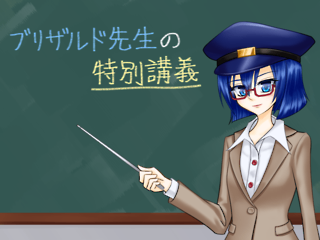

等倍ではわかりづらいが、帽子のあたりに顕著にディザが出ている。

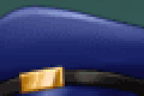

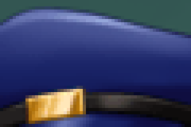

### 原理

下記のように、似た色ごとに4つにわけたピクチャを用意し、それぞれ透過ありで4枚同時に重ねて表示している。

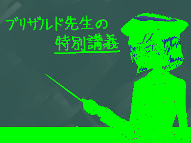

[figure not shown]

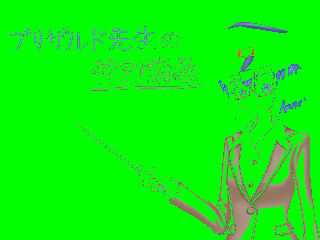

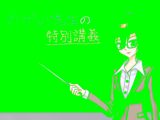

※このゲーム内でも同じ画像を使ってます。

この画像生成に、ImageMagickを利用しています。

### ImageMagickコマンド

コマンドだけでは1発で終わらせられないので、分割して記載。

入力画像は、リサイズのみ終わっており、色自体はフルカラーの状態で用意(lr_top-base.png)

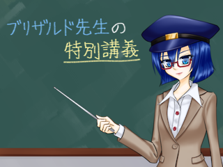

ベース画像

まずは、4色に減色した画像の生成。

```
magick lr_top-base.png +dither -colors 4 tmp/lr_top.png
```

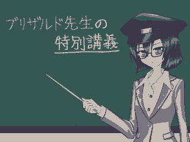

4色

続いて、減色後の画像から、使用している色情報を取得

```
magick convert tmp/lr_top.png -format %c histogram:info:
```

コマンド実行結果

```
49279: ( 53, 88, 83) #355853 srgb(53,88,83)
 8137: ( 60, 55, 73) #3C3749 srgb(60,55,73)
 7814: (122,118,128) #7A7680 srgb(122,118,128)
11570: (198,189,180) #C6BDB4 srgb(198,189,180)
```

上記で取得したカラーコードを使って、画像の指定した色「以外」を削除するためのマスク画像を作成。

```
magick tmp/lr_top.png -fill transparent -opaque '#355853' matte:tmp/mask.matte
magick tmp/mask.matte -negate tmp/mask.png
```

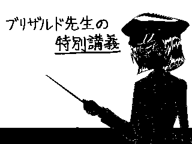

マスク画像

元のフルカラー画像に、上記のマスク画像をもとに、ツクール上の透過色（真緑）を合成。

```
magick -size 320x240 xc:#00FF00 \( tmp/mask.png -alpha copy \) \
  -alpha Set -composite -fill transparent -opaque '#FFFFFF' PNG32:tmp/tmp.png
magick lr_top-base.png tmp/tmp.png -composite lr_top-1.png
```

後は、残り3色に対しても同様の手順で画像を生成し、最後にお好きな減色ツールで減色すれば、4倍色用ピクチャの完成。

### シェル版

上記を基に、自動で4倍色用ピクチャを生成するシェルスクリプトは下記。  
IN_DIRに入れた画像が、まとめて変換されるようになっている。  
参考までにどうぞ。

リサイズと減色も面倒なので、このスクリプト上で行うようになっている。

```
#!/bin/bash

IN_DIR=4xcut/in/
OUT_DIR=4xcut/out/
RESIZED_DIR=4xcut/resized/
TMP_DIR=4xcut/tmp/

rm ${OUT_DIR}*.png ${RESIZED_DIR}*.png ${TMP_DIR}*.png

for img in ${IN_DIR}*.png; do
  filename=`basename "${img}"`
  magick ${img} -resize 320x -filter Lanczos2 -unsharp 0x0.75+0.5+0.25 ${RESIZED_DIR}${filename}
  magick ${RESIZED_DIR}${filename} +dither -colors 4 ${TMP_DIR}${filename}

  i=1
  magick convert ${TMP_DIR}${filename} -format %c histogram:info: | while read -r line;
  do
    hex=`echo $line | sed -e "s/^[^#]*\(#......\).*$/\1/"`;
    magick ${TMP_DIR}${filename} -fill transparent -opaque ${hex} matte:${TMP_DIR}mask.matte
    magick ${TMP_DIR}mask.matte -negate ${TMP_DIR}mask.png
    magick -size 320x240 xc:#00FF00 \( ${TMP_DIR}mask.png -alpha copy \) -alpha Set -composite -fill transparent -opaque '#FFFFFF' PNG32:${TMP_DIR}tmp.png
    magick ${RESIZED_DIR}${filename} ${TMP_DIR}tmp.png -composite ${OUT_DIR}${filename%.*}-${i}.png
    i=$((i + 1))
  done;

done

pngquant 255 ${OUT_DIR}*.png --ext .png --force --speed=1
```

## あとがき

中の人が、tktkの時に使っているコマンドは、だいたい上記を応用したりなんやかんやしてる物になります。

とにかく強力なツールなので、ぜひ、使ってみてください。

私自身、ImageMagickは、毎度毎度ドキュメントを漁りながら、試行錯誤して使っている状況ですので、もっとシンプルな記述方法があったりするかもしれません。  
あくまでも一例として、参考にしていただければ幸いです。

2020.5.某日 lpre_ys